# Project 2: INVESTIGATE A DATASET

### Titanic Data

In this project, we investigate titanic data set and find general patterns in data with emphasis on survival chanches of a passenger depending upon its attributes.

## DATA WRANGLING

In this step, we would read the data and clean it as required.

```python
# import numpy and panda libraries needed
import numpy as np
import pandas as pd

# libraries for plots
import matplotlib.pyplot as plt
%matplotlib inline
```

```python
# Read student data
titanic_data = pd.read_csv("titanic_data.csv")
print "Titantic data read successfully!"
```

```
Titantic data read successfully!
```

```python
print("NUMBER OF PASSENGERS: %s" % len(titanic_data.index))
```

```
NUMBER OF PASSENGERS: 891
```

```python
print("NUMBER OF FEATURES: %s" % len(titanic_data.columns))
```

```
NUMBER OF FEATURES: 12
```

```python
# Below are columns of data
titanic_data.columns
```

```
Index([u'PassengerId', u'Survived', u'Pclass', u'Name', u'Sex', u'Age',
       u'SibSp', u'Parch', u'Ticket', u'Fare', u'Cabin', u'Embarked'],
      dtype='object')
```

```python
# general characteristics of data
titanic_data.describe()
```

|  | PassengerId | Survived | Pclass | Age | SibSp | Parch | Fare |
| --- | --- | --- | --- | --- | --- | --- | --- |
| count | 891.000000 | 891.000000 | 891.000000 | 714.000000 | 891.000000 | 891.000000 | 891.000000 |
| mean | 446.000000 | 0.383838 | 2.308642 | 29.699118 | 0.523008 | 0.381594 | 32.204208 |
| std | 257.353842 | 0.486592 | 0.836071 | 14.526497 | 1.102743 | 0.806057 | 49.693429 |
| min | 1.000000 | 0.000000 | 1.000000 | 0.420000 | 0.000000 | 0.000000 | 0.000000 |
| 25% | 223.500000 | 0.000000 | 2.000000 | 20.125000 | 0.000000 | 0.000000 | 7.910400 |
| 50% | 446.000000 | 0.000000 | 3.000000 | 28.000000 | 0.000000 | 0.000000 | 14.454200 |
| 75% | 668.500000 | 1.000000 | 3.000000 | 38.000000 | 1.000000 | 0.000000 | 31.000000 |
| max | 891.000000 | 1.000000 | 3.000000 | 80.000000 | 8.000000 | 6.000000 | 512.329200 |

```python
titanic_data.head(5)
```

|  | PassengerId | Survived | Pclass | Name | Sex | Age | SibSp | Parch | Ticket | Fare | Cabin | Embarked |
| --- | --- | --- | --- | --- | --- | --- | --- | --- | --- | --- | --- | --- |
| 0 | 1 | 0 | 3 | Braund, Mr. Owen Harris | male | 22 | 1 | 0 | A/5 21171 | 7.2500 | NaN | S |
| 1 | 2 | 1 | 1 | Cumings, Mrs. John Bradley (Florence Briggs Th... | female | 38 | 1 | 0 | PC 17599 | 71.2833 | C85 | C |
| 2 | 3 | 1 | 3 | Heikkinen, Miss. Laina | female | 26 | 0 | 0 | STON/O2. 3101282 | 7.9250 | NaN | S |
| 3 | 4 | 1 | 1 | Futrelle, Mrs. Jacques Heath (Lily May Peel) | female | 35 | 1 | 0 | 113803 | 53.1000 | C123 | S |
| 4 | 5 | 0 | 3 | Allen, Mr. William Henry | male | 35 | 0 | 0 | 373450 | 8.0500 | NaN | S |

```python
# check if there are NULL values in data
titanic_data.apply(lambda x: x.isnull().value_counts())
```

|  | PassengerId | Survived | Pclass | Name | Sex | Age | SibSp | Parch | Ticket | Fare | Cabin | Embarked |
| --- | --- | --- | --- | --- | --- | --- | --- | --- | --- | --- | --- | --- |
| False | 891 | 891 | 891 | 891 | 891 | 714 | 891 | 891 | 891 | 891 | 204 | 889 |
| True | NaN | NaN | NaN | NaN | NaN | 177 | NaN | NaN | NaN | NaN | 687 | 2 |

Based of data above, we do following clean-up in data frame

1) Drop the 'Cabin' column as most of values are null.  
2) Replace missing entries in 'Age' with mean of valid columns.

```python
# drop 'Cabin' table
titanic_data.drop([col for col in ['Cabin'] if col in titanic_data], axis = 1, inplace = True)

# impute missing ages with mean 'Age'
meanAge = np.mean(titanic_data.Age)
titanic_data.Age = titanic_data.Age.fillna(meanAge)
titanic_data.apply(lambda x: x.isnull().value_counts())
```

|  | PassengerId | Survived | Pclass | Name | Sex | Age | SibSp | Parch | Ticket | Fare | Embarked |
| --- | --- | --- | --- | --- | --- | --- | --- | --- | --- | --- | --- |
| False | 891 | 891 | 891 | 891 | 891 | 891 | 891 | 891 | 891 | 891 | 889 |
| True | NaN | NaN | NaN | NaN | NaN | NaN | NaN | NaN | NaN | NaN | 2 |

Above is new table for null check after clean-up

## DATA EXPLORATION

In this step, we would do exploratory analysis of data. It involves visualizing charateristics of data, creating hypothesis and statistically verifiying these hypothesis for survival of passengers.

```python
# plot bar chart for a particular column of categorical type data
def plotCategory(col):
    titanic_data[col].value_counts().plot(kind = 'bar')
    plt.xlabel(col)
    plt.ylabel("count")
    plt.title("Distribution of %s" % col)
```

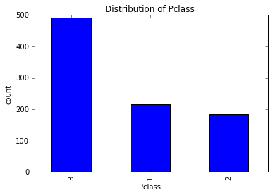

```python
plotCategory('Pclass')
```

In above diagram, we find that most of passenger were in lowest category.

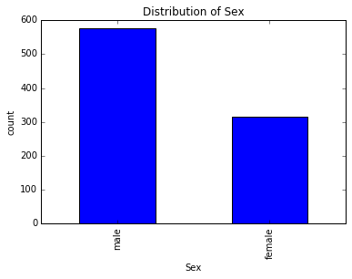

```python
plotCategory('Sex')
```

In above diagram, we find that proportion of male passengers were higher.

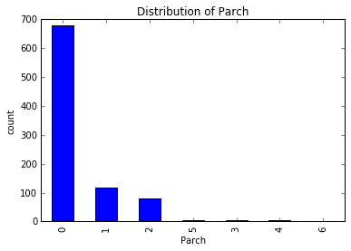

```python
plotCategory('Parch')
```

In above diagram, we see that most of passengers were without parent/child.

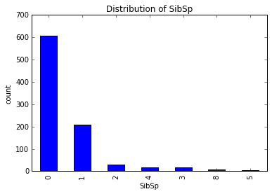

```python
plotCategory('SibSp')
```

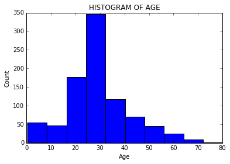

```python
plt.hist(titanic_data['Age'])
plt.title('HISTOGRAM OF AGE')
plt.xlabel('Age')
plt.ylabel('Count')
```

For facilitating in better analysis of data, we convert continuous 'Age' variable to categorical type.

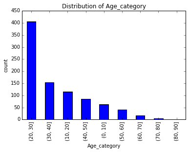

```python
bins = [0,10,20,30,40,50,60,70,80,90]
titanic_data['Age_category'] = pd.cut(titanic_data.Age, bins)
plotCategory('Age_category')
```

Above tables shows that most of passengers were young and were in [20-30] years range.

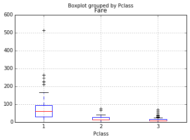

```python
titanic_data.boxplot(column='Fare', by = 'Pclass')
```

As expected, 1st class has higher Fares compared to other class.

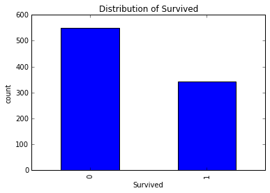

```python
plotCategory('Survived')
```

We see that most of people perished in tragic accident. Next we try to see if there were any privilges for those who survived.

```python
def plotSurvival(col):
    temp = pd.crosstab(titanic_data[col], titanic_data.Survived.astype(bool))
    temp.plot(kind = 'bar', stacked = True)
    plt.title("Survival frequency by %s" % col)
```

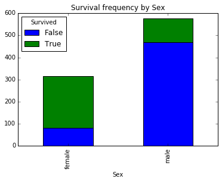

```python
plotSurvival('Sex')
```

Larger green portion in female section indicates that female had higher chances of survival.

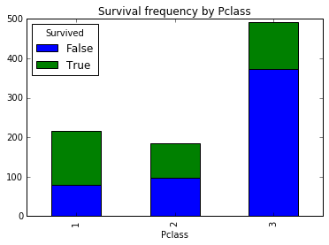

```python
plotSurvival('Pclass')
```

Larger green portion in higher class section indicates that those in 1st class had higher categories of survival.

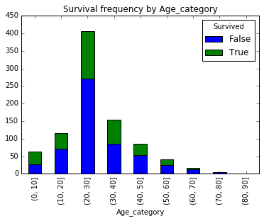

```python
plotSurvival('Age_category')
```

We can see above that childeren (Age < 10) had higher probability of survival.

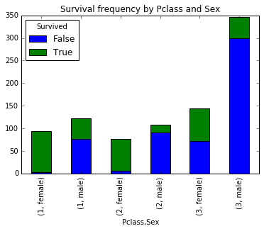

```python
temp = pd.crosstab([titanic_data.Pclass, titanic_data.Sex], titanic_data.Survived.astype(bool))
temp.plot(kind = 'bar', stacked = True)
plt.title("Survival frequency by Pclass and Sex")
```

Above table shows that female of 1st category class had maximum probability of survival.

Based on above visualizations, we make following NULL hypothesis:-  
1) Chances of survival doesn't depend upon Gender  
2) Chances of survival doesn't depend upon class of travel(Pclass)

Below we check statistical test of above hypothesis with critical value of P = 0.05

```python
temp = pd.crosstab(titanic_data.Sex, titanic_data.Survived.astype(bool))
temp
```

| Survived Sex | False | True |
| --- | --- | --- |
| female | 81 | 233 |
| male | 468 | 109 |

```python
from scipy.stats import chi2_contingency
chi2, pval, dof, expected = chi2_contingency(temp)
print chi2, pval, dof, expected
```

```
260.717020167 1.19735706278e-58 1 [[ 193.47474747  120.52525253]
 [ 355.52525253  221.47474747]]
```

As probability (pval) in chi squared independent test is less than critical value, so there are significant difference between female and male survival frequency. Hence NULL hypothesis is false.

```python
temp = pd.crosstab(titanic_data.Pclass, titanic_data.Survived.astype(bool))
temp
```

| Survived Pclass | False | True |
| --- | --- | --- |
| 1 | 80 | 136 |
| 2 | 97 | 87 |
| 3 | 372 | 119 |

```python
chi2, pval, dof, expected = chi2_contingency(temp)
print chi2, pval, dof, expected
```

```
102.888988757 4.5492517113e-23 2 [[ 133.09090909   82.90909091]
 [ 113.37373737   70.62626263]
 [ 302.53535354  188.46464646]]
```

As probability(pval) in chi squared independent test is less than critical value, so there are significant difference between survival frequency of different classes. Hence NULL hypothesis is rejected.

#### LIMITATIONS

Above hypothesis testing have some inherent limitation, which suggests further testing.

- There might be other features affecting relations. For example, it might be case that higher class category passengers are mostly women and children due to which higher class had high survival rates.
- In statistical tests, there is always a probability (though low) of type -1 and type-2 errors. In fact we should calculate power of hypothesis test.
- Chisquare tests only confirm independence of categories. It doesn't tell which class has higher or lower frequencies.